# Parametric bootstrap for mixed-effects models

Authors

Phillip Alday

Reinhold Kliegl

Published

2026-08-26

After working through this page you will be able to:

- explain what the parametric bootstrap does and why it can give more accurate intervals than Wald or other methods based on the standard error;
- run a parametric bootstrap on a fitted `MixedModel`;
- summarize bootstrap replicates into confidence intervals and spot singular fits among them.

**NoteBefore you start**

**Prerequisites:** Analysis of the sleepstudy data.

**Datasets used:** `sleepstudy`, `kb07`, `dyestuff` (see the dataset catalog).

The speed of MixedModels.jl relative to its predecessors makes the parametric bootstrap much more computationally tractable. This is valuable because the parametric bootstrap can be used to produce more accurate confidence intervals than methods based on standard errors or profiling of the likelihood surface.

This page is adapted from the [MixedModels.jl docs](https://juliastats.org/MixedModels.jl/v4/bootstrap/)

# 1 The parametric bootstrap

Bootstrapping is a family of procedures for generating sample values of a statistic, allowing for visualization of the distribution of the statistic or for inference from this sample of values. Bootstrapping also belongs to a larger family of procedures called *resampling*, which are based on creating new samples of data from an existing one, then computing statistics on the new samples, in order to examine the distribution of the relevant statistics.

A *parametric bootstrap* is used with a parametric model, `m`, that has been fit to data. The procedure is to simulate `n` response vectors from `m` using the estimated parameter values and refit `m` to these responses in turn, accumulating the statistics of interest at each iteration.

The parameters of a `LinearMixedModel` object are the fixed-effects parameters (`β`), the standard deviation (`σ`), of the per-observation noise, and the covariance parameter (`θ`), that defines the variance-covariance matrices of the random effects. A technical description of the covariance parameter can be found in the [MixedModels.jl docs](https://juliastats.org/MixedModels.jl/v4.7.1/optimization/). Lisa Schwetlick and Daniel Backhaus have provided a more beginner-friendly description of the covariance parameter in the [documentation for MixedModelsSim.jl](https://repsychling.github.io/MixedModelsSim.jl/v0.2.6/simulation_tutorial/). For today’s purposes – looking at the uncertainty in the estimates from a fitted model – we can simply use values from the fitted model, but we will revisit the parametric bootstrap in power simulation as a convenient way to simulate new data, potentially with different parameter values, for power analysis.

Attach the packages to be used

```julia
using AlgebraOfGraphics
using CairoMakie
using DataFrames
using MixedModels
using MixedModelsMakie
using Random
using MixedModelsDatasets: dataset
using SMLP2026: fit_or_restore

using AlgebraOfGraphics: AlgebraOfGraphics as AoG
const progress = isinteractive()
```

Note that the precise stream of random numbers generated for a given seed can change between Julia versions. For exact reproducibility, you either need to have the exact same Julia version or use the [StableRNGs](https://github.com/JuliaRandom/StableRNGs.jl) package.

# 2 A model of moderate complexity

The `kb07` data (Kronmüller & Barr, 2007) are one of the datasets provided by the `MixedModels` package.

```julia
kb07 = dataset(:kb07)
```

```
Arrow.Table with 1789 rows, 7 columns, and schema:
 :subj      String
 :item      String
 :spkr      String
 :prec      String
 :load      String
 :rt_trunc  Int16
 :rt_raw    Int16
```

Convert the table to a DataFrame for summary.

```julia
kb07 = DataFrame(kb07)
describe(kb07)
```

7×7 DataFrame

| Row | variable Symbol | mean Union… | min Any | median Union… | max Any | nmissing Int64 | eltype DataType |
| --- | --- | --- | --- | --- | --- | --- | --- |
| 1 | subj |  | S030 |  | S103 | 0 | String |
| 2 | item |  | I01 |  | I32 | 0 | String |
| 3 | spkr |  | new |  | old | 0 | String |
| 4 | prec |  | break |  | maintain | 0 | String |
| 5 | load |  | no |  | yes | 0 | String |
| 6 | rt_trunc | 2182.2 | 579 | 1940.0 | 5171 | 0 | Int16 |
| 7 | rt_raw | 2226.24 | 579 | 1940.0 | 15923 | 0 | Int16 |

The experimental factors; `spkr`, `prec`, and `load`, are two-level factors.

```julia
contrasts = Dict(:spkr => EffectsCoding(),
                 :prec => EffectsCoding(),
                 :load => EffectsCoding(),
)
```

The `EffectsCoding` contrast is used with these to create a ±1 encoding.

We can look at an initial fit of moderate complexity:

```julia
form = @formula(rt_trunc ~ 1 + spkr * prec * load +
                          (1 + spkr + prec + load | subj) +
                          (1 + spkr + prec + load | item))
m0 = fit(MixedModel, form, kb07; contrasts, progress)
```

|  | Est. | SE | z | p | σ_subj | σ_item |
| --- | --- | --- | --- | --- | --- | --- |
| (Intercept) | 2181.6727 | 77.2965 | 28.22 | <1e-99 | 301.8071 | 362.1424 |
| spkr: old | 67.7486 | 18.2896 | 3.70 | 0.0002 | 42.9089 | 40.7136 |
| prec: maintain | -333.9211 | 47.1581 | -7.08 | <1e-11 | 62.0140 | 246.9255 |
| load: yes | 78.7704 | 19.5368 | 4.03 | <1e-04 | 65.1404 | 42.3626 |
| spkr: old & prec: maintain | -21.9657 | 15.8061 | -1.39 | 0.1646 |  |  |
| spkr: old & load: yes | 18.3843 | 15.8061 | 1.16 | 0.2448 |  |  |
| prec: maintain & load: yes | 4.5338 | 15.8061 | 0.29 | 0.7742 |  |  |
| spkr: old & prec: maintain & load: yes | 23.6075 | 15.8061 | 1.49 | 0.1353 |  |  |
| Residual | 668.4995 |  |  |  |  |  |

The default display in Quarto uses the [pretty MIME show method](https://juliastats.org/MixedModels.jl/v4.7.1/mime/) for the model and omits the estimated correlations of the random effects.

The `VarCorr` extractor displays these.

```julia
VarCorr(m0)
```

|  | Column | Variance | Std.Dev | Corr. |  |  |
| --- | --- | --- | --- | --- | --- | --- |
| subj | (Intercept) | 91087.5446 | 301.8071 |  |  |  |
|  | spkr: old | 1841.1736 | 42.9089 | +0.78 |  |  |
|  | prec: maintain | 3845.7309 | 62.0140 | -0.59 | +0.02 |  |
|  | load: yes | 4243.2715 | 65.1404 | +0.36 | +0.83 | +0.53 |
| item | (Intercept) | 131147.0985 | 362.1424 |  |  |  |
|  | spkr: old | 1657.6012 | 40.7136 | +0.44 |  |  |
|  | prec: maintain | 60972.1927 | 246.9255 | -0.69 | +0.35 |  |
|  | load: yes | 1794.5887 | 42.3626 | +0.32 | +0.16 | -0.14 |
| Residual |  | 446891.5597 | 668.4995 |  |  |  |

None of the two-factor or three-factor interaction terms in the fixed-effects are significant. In the random-effects terms only the scalar random effects and the `prec` random effect for `item` appear to be warranted, leading to the reduced formula

```julia
# formula f4 from https://doi.org/10.33016/nextjournal.100002
form = @formula(rt_trunc ~ 1 + spkr * prec * load + (1 | subj) + (1 + prec | item))

m1 = fit(MixedModel, form, kb07; contrasts, progress)
```

```julia
VarCorr(m1)
```

|  | Column | Variance | Std.Dev | Corr. |
| --- | --- | --- | --- | --- |
| item | (Intercept) | 133027.438 | 364.729 |  |
|  | prec: maintain | 63841.834 | 252.669 | -0.70 |
| subj | (Intercept) | 88870.013 | 298.111 |  |
| Residual |  | 460948.572 | 678.932 |  |

These two models are nested and can be compared with a likelihood-ratio test.

```julia
MixedModels.likelihoodratiotest(m0, m1)
```

|  | model-dof | -2 logLik | χ² | χ²-dof | P(>χ²) |
| --- | --- | --- | --- | --- | --- |
| rt_trunc ~ 1 + spkr + prec + load + spkr & prec + spkr & load + prec & load + spkr & prec & load + (1 + spkr + prec + load \| subj) + (1 + spkr + prec + load \| item) | 29 | -28637 |  |  |  |
| rt_trunc ~ 1 + spkr + prec + load + spkr & prec + spkr & load + prec & load + spkr & prec & load + (1 \| subj) + (1 + prec \| item) | 13 | -28658 | 21 | -16 | 0.1649 |

# 3 Bootstrap basics

To bootstrap the model parameters, first initialize a random number generator then create a bootstrap sample and extract the table of parameter estimates from it.

```julia
const RNG = MersenneTwister(42)
samp = parametricbootstrap(RNG, 5_000, m1; progress)
tbl = samp.tbl
```

```
Table with 18 columns and 5000 rows:
      obj      β1       β2       β3        β4       β5        β6        ⋯
    ┌────────────────────────────────────────────────────────────────────
 1  │ 28666.1  2173.0   55.5993  -359.306  87.2052  -35.3047  33.0377   ⋯
 2  │ 28710.1  1973.91  88.8248  -313.74   83.7709  -23.1799  -15.9286  ⋯
 3  │ 28582.8  2167.34  48.2284  -297.197  79.0159  -22.0111  41.9171   ⋯
 4  │ 28718.5  2259.43  66.0501  -386.658  82.6574  -35.3235  14.2615   ⋯
 5  │ 28589.3  2182.94  44.9803  -410.528  109.299  -19.1385  42.9881   ⋯
 6  │ 28517.0  2167.97  61.043   -360.569  75.7417  15.1462   61.9219   ⋯
 7  │ 28708.8  2210.25  70.856   -349.679  99.5077  -32.944   16.7733   ⋯
 8  │ 28731.5  2235.07  59.2516  -353.734  58.049   -35.2583  10.0729   ⋯
 9  │ 28731.8  2043.11  72.2606  -300.714  71.0784  -14.1545  10.6162   ⋯
 10 │ 28606.7  2011.05  76.431   -254.577  63.9764  -37.9284  3.92921   ⋯
 11 │ 28643.4  2166.5   71.0285  -324.491  58.3968  -21.5751  -31.4075  ⋯
 12 │ 28660.0  2158.28  64.38    -336.465  80.4072  -39.4399  1.98082   ⋯
 13 │ 28641.5  2147.14  70.6071  -399.78   59.9985  -35.6204  28.5064   ⋯
 14 │ 28682.0  2138.16  75.5171  -262.3    97.0663  -32.1177  26.8657   ⋯
 15 │ 28668.1  2239.36  65.2487  -373.311  83.4486  -29.7478  5.37272   ⋯
 16 │ 28605.0  2088.58  62.0174  -268.102  99.6468  -27.3314  49.5304   ⋯
 17 │ 28531.1  2313.5   61.0588  -338.01   74.7445  -14.5737  48.7751   ⋯
 ⋮  │    ⋮        ⋮        ⋮        ⋮         ⋮        ⋮         ⋮      ⋱
```

**Tip`optsum_overrides`: faster replicates at reduced precision**

The keyword argument `optsum_overrides` passes additional arguments controlling the model fitting of each replicate, e.g. `parametricbootstrap(RNG, 5_000, m1; optsum_overrides=(; ftol_rel=1e-8))`. `ftol_rel=1e-8` lowers the threshold for changes in the objective – more directly, the optimizer considers the model converged if the change in the deviance is less than $10^{-8}$, which is a very small change, but larger than the default $10^{-12}$. Because the majority of the optimization time is spent in final fine-tuning, changing this threshold can greatly speed up the fitting time at the cost of a small loss of quality in fit. For a stochastic process like the bootstrap, that change in quality just adds to the general noise, but that’s an acceptable tradeoff in order to get many more replicates. The MixedModels.jl documentation also includes a little note on the [reduced precision bootstrap](https://juliastats.org/MixedModels.jl/stable/bootstrap/#Reduced-Precision-Bootstrap).

An empirical density plot of the estimates of the residual standard deviation is obtained as

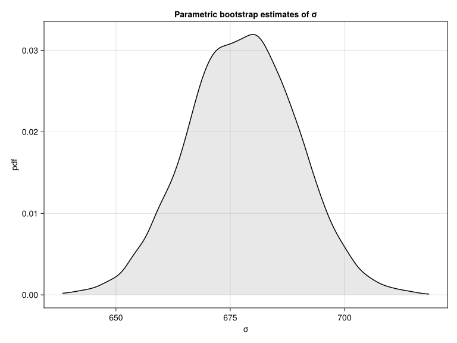

```julia
plt = data(tbl) * mapping(:σ) * AoG.density()
draw(plt; axis=(;title="Parametric bootstrap estimates of σ"))
```

A density plot of the estimates of the standard deviation of the random effects is obtained as

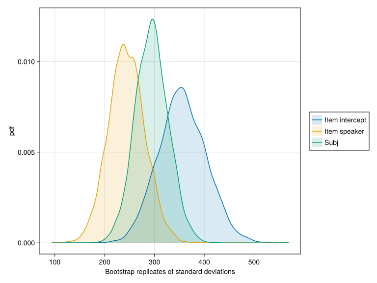

```julia
plt = data(tbl) * mapping(
  [:σ1, :σ2, :σ3] .=> "Bootstrap replicates of standard deviations";
  color=dims(1) => renamer(["Item intercept", "Item speaker", "Subj"])
) * AoG.density()
draw(plt; figure=(;supertitle="Parametric bootstrap estimates of variance components"))
```

The bootstrap sample can be used to generate intervals that cover a certain percentage of the bootstrapped values. We refer to these as “coverage intervals”, similar to a confidence interval. The shortest such intervals, obtained with the `confint` extractor, correspond to a highest posterior density interval in Bayesian inference.

We generate these for all random and fixed effects:

```julia
confint(samp; method=:shortest)
```

```
DictTable with 2 columns and 13 rows:
 par   lower      upper
 ────┬─────────────────────
 β1  │ 2033.37    2332.46
 β2  │ 35.0188    98.4562
 β3  │ -430.963   -246.167
 β4  │ 48.9126    112.362
 β5  │ -51.5002   12.1719
 β6  │ -13.6978   49.6548
 β7  │ -27.2307   34.5997
 β8  │ -6.39206   55.7104
 ρ1  │ -0.898241  -0.458759
 σ   │ 654.495    700.684
 σ1  │ 260.548    445.231
 σ2  │ 172.313    313.725
 σ3  │ 231.042    361.333
```

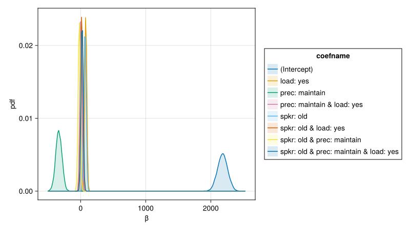

```julia
draw(
  data(samp.β) * mapping(:β; color=:coefname) * AoG.density();
  figure=(; size=(800, 450)),
)
```

For the fixed effects, MixedModelsMakie provides a convenience interface to plot the combined coverage intervals and density plots

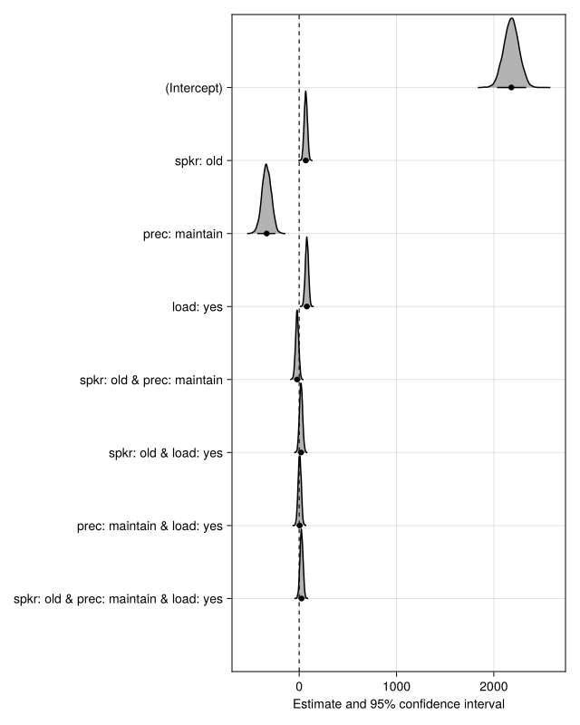

```julia
ridgeplot(samp)
```

Often the intercept will be on a different scale and potentially less interesting, so we can stop it from being included in the plot:

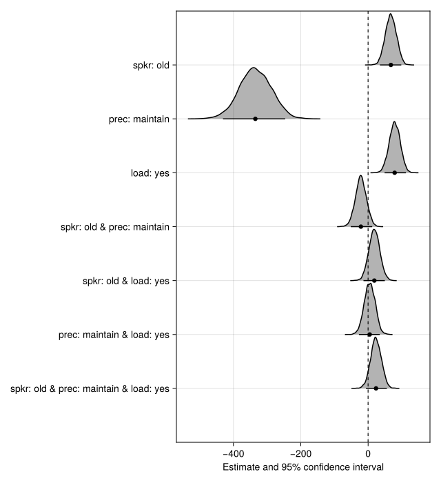

```julia
ridgeplot(samp; show_intercept=false)
```

# 4 Singularity

Let’s consider the classic dyestuff dataset:

```julia
dyestuff = dataset(:dyestuff)
mdye = fit(MixedModel, @formula(yield ~ 1 + (1 | batch)), dyestuff)
```

```julia
sampdye = parametricbootstrap(MersenneTwister(1234321), 10_000, mdye)
tbldye = sampdye.tbl
```

```
Table with 5 columns and 10000 rows:
      obj      β1       σ        σ1       θ1
    ┌─────────────────────────────────────────────
 1  │ 316.738  1528.14  43.5735  22.6691  0.520249
 2  │ 336.101  1552.01  58.1535  39.5166  0.679521
 3  │ 322.046  1501.55  51.857   0.0      0.0
 4  │ 326.893  1525.24  43.6512  66.3744  1.52057
 5  │ 331.544  1522.05  50.7415  51.0074  1.00524
 6  │ 326.892  1550.23  53.5174  19.0928  0.356759
 7  │ 313.786  1504.16  45.1878  0.0      0.0
 8  │ 322.636  1494.05  49.8556  17.7733  0.356494
 9  │ 323.582  1529.74  46.4678  35.2094  0.757716
 10 │ 321.639  1532.6   45.3573  32.4904  0.71632
 11 │ 331.565  1548.25  55.8562  28.7512  0.514736
 12 │ 310.076  1481.8   34.9418  38.4381  1.10006
 13 │ 314.492  1541.95  40.3751  28.3694  0.702646
 14 │ 340.876  1530.48  63.006   42.6409  0.676776
 15 │ 309.778  1496.17  41.5411  8.08345  0.194589
 16 │ 335.375  1530.32  57.4864  38.9066  0.676797
 17 │ 318.347  1511.28  41.0926  39.1128  0.95182
 ⋮  │    ⋮        ⋮        ⋮        ⋮        ⋮
```

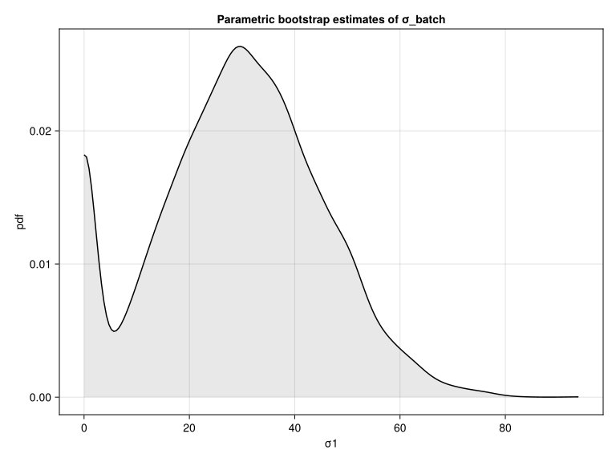

```julia
plt = data(tbldye) * mapping(:σ1) * AoG.density()
draw(plt; axis=(;title="Parametric bootstrap estimates of σ_batch"))
```

Notice that this density plot has a spike, or mode, at zero. Although this mode appears to be diffuse, this is an artifact of the way that density plots are created. In fact, it is a pulse, as can be seen from a histogram.

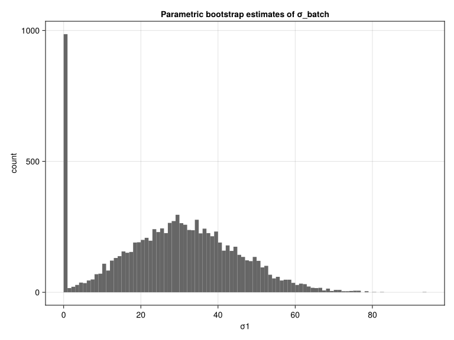

```julia
plt = data(tbldye) * mapping(:σ1) * AoG.histogram(;bins=100)
draw(plt; axis=(;title="Parametric bootstrap estimates of σ_batch"))
```

A value of zero for the standard deviation of the random effects is an example of a *singular* covariance. It is easy to detect the singularity in the case of a scalar random-effects term. However, it is not as straightforward to detect singularity in vector-valued random-effects terms.

For example, if we bootstrap a model fit to the `sleepstudy` data

```julia
sleepstudy = dataset(:sleepstudy)
msleep = fit(MixedModel, @formula(reaction ~ 1 + days + (1 + days | subj)),
             sleepstudy)
```

```julia
sampsleep = parametricbootstrap(MersenneTwister(666), 10_000, msleep)
tblsleep = sampsleep.tbl
```

```
Table with 10 columns and 10000 rows:
      obj      β1       β2       σ        σ1       σ2       ρ1           ⋯
    ┌─────────────────────────────────────────────────────────────────────
 1  │ 1694.07  258.109  10.7928  22.1713  13.639   5.42874  0.430476     ⋯
 2  │ 1731.59  241.267  9.77437  23.5943  23.8822  7.07987  -0.277573    ⋯
 3  │ 1706.51  254.403  10.6731  23.0742  21.4347  3.78776  0.493341     ⋯
 4  │ 1737.33  257.833  7.61743  24.5027  27.2653  4.85669  -0.0191323   ⋯
 5  │ 1764.5   244.154  13.0045  25.8322  30.9872  7.78257  -0.532291    ⋯
 6  │ 1730.85  247.672  13.2977  24.3583  18.6133  5.87767  -0.0542254   ⋯
 7  │ 1709.66  256.847  8.60196  22.4272  26.8869  6.62172  -0.637998    ⋯
 8  │ 1776.49  252.028  9.56227  27.3707  27.7005  6.53338  -0.353799    ⋯
 9  │ 1732.12  248.687  11.5173  23.7153  22.2867  6.69778  0.304229     ⋯
 10 │ 1748.89  249.387  10.2581  25.3961  24.7506  5.44657  0.00470547   ⋯
 11 │ 1735.34  247.16   8.57303  25.5931  19.2141  3.9918   1.0          ⋯
 12 │ 1757.34  248.074  9.7696   25.9833  29.2858  4.74155  0.216293     ⋯
 13 │ 1727.32  248.007  12.8942  23.9316  32.176   3.50424  0.152037     ⋯
 14 │ 1753.38  252.684  9.88844  25.2124  21.3448  7.64865  -0.00704676  ⋯
 15 │ 1731.05  262.218  7.70813  25.0737  18.1157  4.89353  -0.280415    ⋯
 16 │ 1742.68  252.273  12.7376  24.4489  20.684   7.47363  0.0242163    ⋯
 17 │ 1727.37  243.956  12.107   24.6337  26.502   3.89649  -0.411467    ⋯
 ⋮  │    ⋮        ⋮        ⋮        ⋮        ⋮        ⋮          ⋮       ⋱
```

the singularity can be exhibited as a standard deviation of zero or as a correlation of ±1.

```julia
confint(sampsleep)
```

```
DictTable with 2 columns and 6 rows:
 par   lower     upper
 ────┬──────────────────
 β1  │ 238.265   264.28
 β2  │ 7.56524   13.4072
 ρ1  │ -0.40997  1.0
 σ   │ 22.6674   28.5759
 σ1  │ 10.5608   33.258
 σ2  │ 3.08371   7.73195
```

A histogram of the estimated correlations from the bootstrap sample has a spike at `+1`.

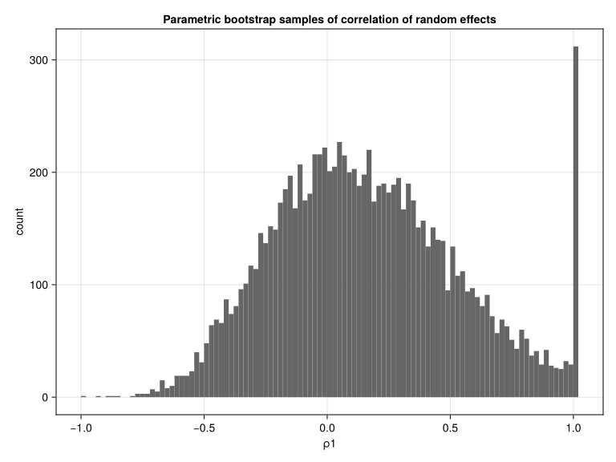

```julia
plt = data(tblsleep) * mapping(:ρ1) * AoG.histogram(;bins=100)
draw(plt; axis=(;title="Parametric bootstrap samples of correlation of random effects"))
```

or, as a count,

```julia
count(tblsleep.ρ1  .≈ 1)
```

```
312
```

```julia
count(tblsleep.ρ1 .≈ -1)
```

```
0
```

```julia
count(tblsleep.σ1 .≈ 0)
```

```
1
```

There is a general condition to check for singularity of an estimated covariance matrix or matrices in a bootstrap sample. The parameter optimized in the estimation is `θ`, the relative covariance parameter. Some of the elements of this parameter vector must be non-negative and, when one of these components is approximately zero, one of the covariance matrices will be singular.

The `issingular` method for a `MixedModel` object that tests if a parameter vector `θ` corresponds to a boundary or singular fit.

This operation is encapsulated in a method for the `issingular` function that works on `MixedModelBootstrap` objects.

```julia
count(issingular(sampsleep))
```

```
313
```

# 5 See Also

- Confidence Intervals from Profiled Objective — an alternative approach to uncertainty quantification via likelihood profiling rather than simulation.
- Using simulation to estimate uncertainty and power — the same simulate-refit machinery applied to designs you have not run yet.
- The [introductory chapter](https://www.embraceuncertaintybook.com/intro.html) of *Embrace Uncertainty* — the theory behind the parametric bootstrap and coverage intervals, on the simplest possible example.

# 6 References

Kronmüller, E., & Barr, D. J. (2007). Perspective-free pragmatics: Broken precedents and the recovery-from-preemption hypothesis. *Journal of Memory and Language*, *56*(3), 436–455. https://doi.org/10.1016/j.jml.2006.05.002

## 6.1 Exercises

1. **A small bootstrap.** Run a parametric bootstrap with a modest number of replicates on the `sleepstudy` random-slope model and report a 95% confidence interval for the `days` effect.

**NoteSolution**

Use a fixed RNG for reproducibility and `shortestcovint` (or the `confint` method) on the bootstrap object.

```julia
using Random
df = DataFrame(dataset(:sleepstudy))
m = fit(MixedModel, @formula(reaction ~ 1 + days + (1 + days | subj)), df)
boot = parametricbootstrap(MersenneTwister(42), 1000, m)
DataFrame(shortestcovint(boot))
```

2. **Count the singular fits.** Of your bootstrap replicates, how many produced a singular fit? Why does that matter for interpreting the bootstrap distribution of the correlation parameter?

**NoteSolution**

`count(issingular, boot)` (or inspecting the relevant column) gives the number of singular replicates. A large fraction of singular fits means the correlation parameter is poorly identified, so its bootstrap distribution piles up at ±1 and its confidence interval should be read with caution.

*This page was rendered from git revision [29e8d33](https://github.com/RePsychLing/SMLP2026/tree/29e8d33  
) using Quarto 1.10.18 and Julia 1.12.7.*

Back to top